# Principal Component Analysis

Author

Affiliation

Tomoyuki Aota

Nagasaki University

Published

June 7, 2025

# What is PCA ?

大規模なデータは様々な分野で扱われるが, このようなデータを解釈する際は, データのほとんどの情報が保持されるように, 解釈可能な方法で次元を減らす方法が必要です (Jolliffe and Cadima 2016).

主成分分析 (Principal Component Analysis; PCA) は, 高次元のデータを低次元で説明するための次元縮約の一つです. 高次元のデータに関して, 分散が最も大きくなる次元 (主成分; PC) を探す方法です. 主成分とは, データの特徴を表す要素で, 元のデータがもつそれぞれの要素をより少ない要素で表します. このような主成分を見つけることは, 固有値問題に帰着します.

ここでは, PCA の概要を解説していきます. R での実装は [GitHub-pca_workspace](https://github.com/Tomo-Aot/github_practice/blob/main/Data_analysis/pca_workspace.R) を参考にしてください.

## 直感的な解釈

いきなり数式を持ち出すとわかりにくいかもしれないので, はじめに直感的に理解できるように図を使って説明します. 下の図のような直交座標系にプロットされたデータについて考えます.

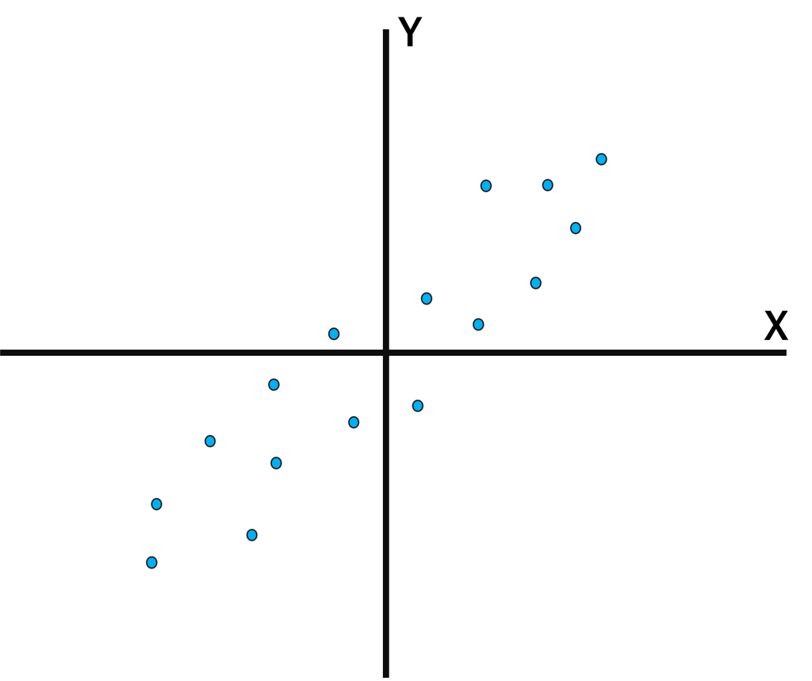

Fig. 1. 直交座標系における散布図

いくつかの変数から X と Y の二つの要素に関する散布図を作成しました. しかし, 我々が持っているデータはもっとたくさんのデータがあります. 他の要素との関係も見なければいけない場合, 高次元の図を作って調べなければいけないです. しかし, これは現実的に難しい課題です. ここで, X と Y が持つそれぞれの情報量に着目します.

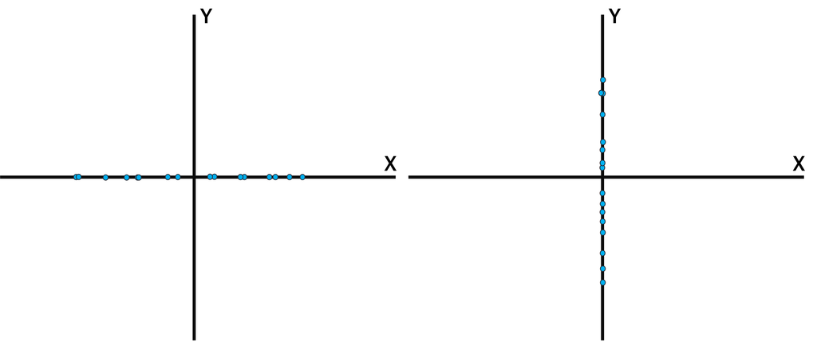

Fig. 2. 次元の縮約

図のように X 軸と Y 軸について注目すると, 点同士が重なることもあります. なるべくデータが持つ情報量を減らしたくないですよね. そこで, X と Y について最も分散が大きい軸を探してみます.

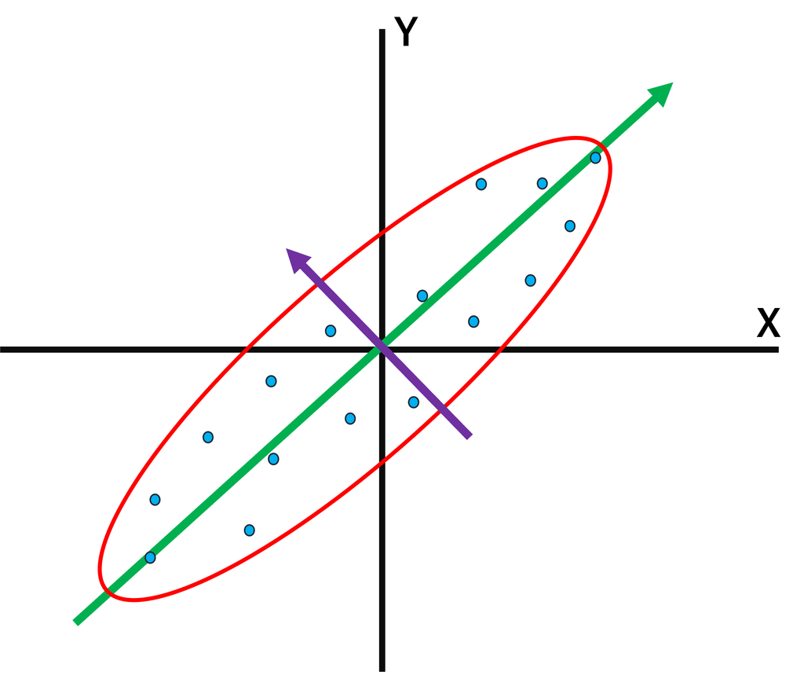

Fig. 3. 主成分軸の探索

図の緑の矢印は 2 つの要素の分散が最も大きくなる軸です. これが PC1 になります. PC1 に垂直な成分は PC2 です (紫の矢印). PCA は要素同士の関係から分散の大きい新しい要素 (主成分) を探索します. PC1 のようにわかりやすい要素が見つかると嬉しいですね. 身近な例として, 身長と体重から算出される BMI は身長と体重を一つの指標として表します. これも PCA と近い考え方です.

# 前提知識

## 偏微分

ある与えられた関数 $f(x,y)$ について, 関数 $f(x, y)$ の $x$ に対する偏微分は以下で定義されます (Eq. 1).

$$\frac{\partial{f}}{\partial{x}}=
\lim_{\Delta{x}\rightarrow{0}}
\frac{f(x + \Delta{x}, y) - f(x,y)}{\Delta{x}}
\tag{1}$$

## 転置行列

n 次元 p 行の行列 $A$ について考えます. 行列の行と列を入れ替える操作を転置 (Transpose) といい, $A'$ もしくは $A^T$ で表されます (Fig. 4).

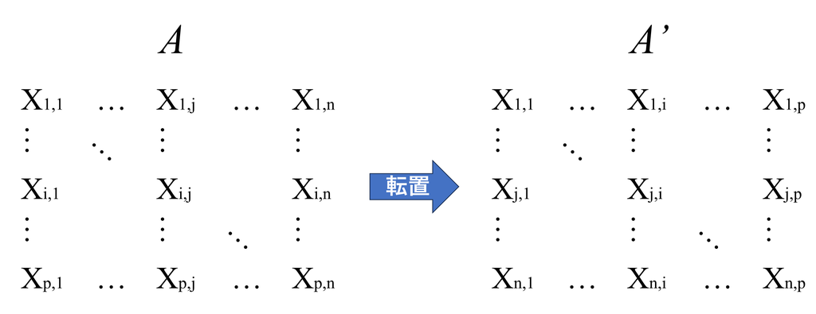

Fig. 4. 行列の転置のイメージ

厳密な方法はここでは省略します. ここで重要な点は, 転置行列の概念だけです.

## 固有値と固有ベクトル

n 次正方行列 $A$ について, 以下のベクトル方程式を考えます.

$$Ax = \lambda x
\tag{2}$$

ただし, x ≠ 0 です. このとき, $\lambda$ を$A$ の固有値 (Eigenvalue) といい, $x$ を $\lambda$ に関する固有ベクトル (Eigenvector) と言います. また, 先の式を次のように変形することができます.

$$(\lambda I - A)x = 0
\tag{3}$$

この時, x ≠ 0 である必要があるため, 以下のように表されます.

$$det(\lambda I - A)=0
\tag{4}$$

この時, det は行列式を表します. この式から, n 次正方行列 A について上記の式が成り立つとき, $\lambda$ は行列 A の固有値です.

# 主成分の計算

n $\times$ p の行列を用意します. これは n 次元 p 行 ($x_1$, $\cdots$, $x_p$) のデータです.

$$\begin{vmatrix}
x_{11} & \cdots & x_{1i} & \cdots & x_{1n}\\
\vdots & \ddots & & & \vdots \\
x_{j1} & & x_{ji} & & x_{jn} \\
\vdots & & & \ddots & \vdots \\
x_{p1} & \cdots & x_{pi} & \cdots & x_{pn}
\end{vmatrix}
\tag{5}$$

ここで, $x_1$, $\cdots$, $x_p$ は p 列のベクトルを表します. PCA では, データの各変数がベクトルとして扱われます. それらを線形結合して, 主成分を作ります. 線形結合とは, いくつかのベクトルを特定の係数で加算する操作です. あるベクトル $\boldsymbol{Xa}$ の線形結合は次のようにあらわされます (2).

$$\boldsymbol{Xa}=a_1\boldsymbol{x}_1+
\cdots+a_p\boldsymbol{x}_p
=\sum_{j=1}^{p}a_jx_j
\tag{6}$$

ここで, $a_1$, $\cdots$, $a_p$ は PCA によって求められる係数で, 定数のベクトル $\boldsymbol{a}$ です. 各変数に対して, 最大の分散を持つ行列の線形結合を探索します. このような線形結合の分散は以下のように表されます (Eq. 4).

$$var(\boldsymbol{X}
\boldsymbol{a}) =
\boldsymbol{a}'S\boldsymbol{a}
\tag{7}$$

ここで, $\boldsymbol{a}$ は主成分を計算するための重みづけベクトル, $S$ はデータに関連付けられた共分散行列 (p×pの正方行列), $'$ は転置を表します. これは二次形式であり, 以下の式で表すことができます.

$$\boldsymbol{a}'S\boldsymbol{a}=
\begin{pmatrix}
a_1 & a_2 & \cdots & a_p
\end{pmatrix}
\begin{pmatrix}
S_{11} & \cdots & S_{1p}\\
\vdots & \ddots & \vdots \\
S_{p1} & \cdots & S_{pp}
\end{pmatrix}
\begin{pmatrix}
a_1 \\
a_2 \\
\vdots \\
a_p
\end{pmatrix}
\tag{8}$$

この式を展開すると以下のように表されます.

$$\boldsymbol{a}'S\boldsymbol{a}=
\sum_{i=1}^{p}\sum_{j=1}^{p}a_iS_{ij}a_j
\tag{9}$$

## ラグランジュ乗数法による最適化問題

先の問題を明確に定義するためには, 追加の制限を課す必要があります. 最も一般的な制限は単位ノルムベクトルを使用することです. ここではラグランジュ乗数法を用いて解く過程を説明します.

まず, PCA において, 主成分を求めるという問題があります. この主成分の方向を表すベクトルは, 元のデータにおける変数の線形結合として定義されます. ここで, 最適な主成分を探索するために以下の 2 点を考慮する必要があります.

・$var(\boldsymbol{X}\boldsymbol{a})=\boldsymbol{a}'S\boldsymbol{a}$ を最大化する。

・$\boldsymbol{a}$ の長さ（ノルム）が 1 であること. この制約は, 長さが異なる方向を排除し, 最適な方向を一意に定めます. 数式で表すと以下のようになります (4).

$$\boldsymbol{a}'\boldsymbol{a}=1
\tag{10}$$

これらの制約を加えた最適化問題を解くために, ラグランジュ乗数法を導入します. ここで, 目的関数は以下のように記述できます (5).

$$\boldsymbol{a}'S\boldsymbol{a}
\tag{11}$$

ただし, 先に加えた制約条件を考慮します. ラグランジュ乗数法を使うと, 制約付き最適化問題は以下のように記述されます (6).

$$L(a,\lambda)
=\boldsymbol{a}'S\boldsymbol{a}
- \lambda(\boldsymbol{a}'\boldsymbol{a}-1)
\tag{12}$$

ここで, $\lambda$ はラグランジュ乗数を表します. このとき, $\boldsymbol{a}'S\boldsymbol{a}$ の分散を最大化することを目指します.

次に, ラグランジュ関数 $L(a,\lambda)$ を使って, 最適なベクトル $\boldsymbol{a}$ とラグランジュ乗数 $\lambda$ を求めるために, ラグランジュ関数を $\boldsymbol{a}$ と $\lambda$ について微分し, それを 0 に設定します.

微分した結果, $S\boldsymbol{a} = \lambda\boldsymbol{a}$ となります. この式は固有値問題の形になっています.

$\lambda$ について微分すると, 制約条件が得られます (8).

$$\frac{\partial L}{\partial \lambda}
=-(\boldsymbol{a}'\boldsymbol{a}-1)=0
\tag{14}$$

これにより, 制約条件 $\boldsymbol{a}'\boldsymbol{a}=1$ が確認できます.

ここで得られた式 $S\boldsymbol{a} = \lambda\boldsymbol{a}$ について, 共分散行列 $S$ の固有値問題を表しており, $S$ の固有ベクトル $\boldsymbol{a}$ とその固有値 $\lambda$ を求める問題です. 固有値は主成分の分散を表し, 最大の固有値に対応する固有ベクトルが主成分を表します.

PCA の目的は, 最大の分散を持つ主成分の探索です. 最大分散を持つ主成分は, 最大の固有値 $\lambda_1$ に対応する固有ベクトル $a_1$ です. これは第一主成分で, データの中で最も重要な方向を示します. その方向にデータを投影することで次元を減らします. 二番目に分散が大きい固有値とそれに対応する固有ベクトルは第二主成分を示します. このようにして, n 個の主成分 (固有ベクトル) を得ることができます. これらの主成分は, たがいに直行しており, データの次元を減らすための新しい軸を提供します.

また, PCA のもう一つの重要な特徴として, 得られる主成分が無相関であることです (“Principal Component Analysis for Special Types of Data” 2002). つまり, 主成分間の共分散が 0 になり, 固有ベクトルの内積が 0 になります. 固有ベクトルは, 各主成分が元の変数にどれだけ寄与しているかを示す重み (寄与率) であり, 主成分得点は線形結合の結果で示されます. この値は, 各データポイントが各主成分でどの位置にあるかを示します.

# バイプロット

ここまでは数式による表現でしたが、 この結果を図示することで、 より解析の解釈が直感的になります。 ここでは、 Iris を使用した PCA の結果を図示します。

はじめに、データを読み込みます。 結果は以下の通りです。

```
# A tibble: 150 × 5
  Sepal.Length Sepal.Width Petal.Length Petal.Width Species
         <dbl>       <dbl>        <dbl>       <dbl> <fct>
1          5.1         3.5          1.4         0.2 setosa
2          4.9         3            1.4         0.2 setosa
3          4.7         3.2          1.3         0.2 setosa
4          4.6         3.1          1.5         0.2 setosa
5          5           3.6          1.4         0.2 setosa
# ℹ 145 more rows
```

合計 150 行のデータで構成されていることが分かります。 このフレームには 3 種のアヤメ (Genus *Iris*) に関する花弁と蕚の情報がまとめられています。 ここでは、 それぞれの種ごとにどのような傾向があるのか PCA で調べてみます。

次に、PCA に導入するために、 行列に変換します。 変換後に行列内の全ての変数を標準化します。 標準化が完了すると、 データを PCA に導入することができます。 PCA の結果は以下の通りです。

```
Call: rda(X = matrix)

              Inertia Rank
Total               4
Unconstrained       4    4
Inertia is variance

Eigenvalues for unconstrained axes:
   PC1    PC2    PC3    PC4
2.9185 0.9140 0.1468 0.0207
```

この表の Unconstrained は制約条件なしのばらつきを表します。 また、**Eigenvalues for unconstrained axes** はそれぞれの主成分の固有値を表します。 ここでは、主成分が PC1 から PC4 まであることがわかります。 つぎに、それぞれの主成分の寄与率を計算していきます。 寄与率を計算することで、 それぞれの主成分がデータのばらつきをどれくらい説明しているかがわかります。 寄与率は、各主成分の固有値を全ての主成分の固有値の合計で割ることで算出できます。

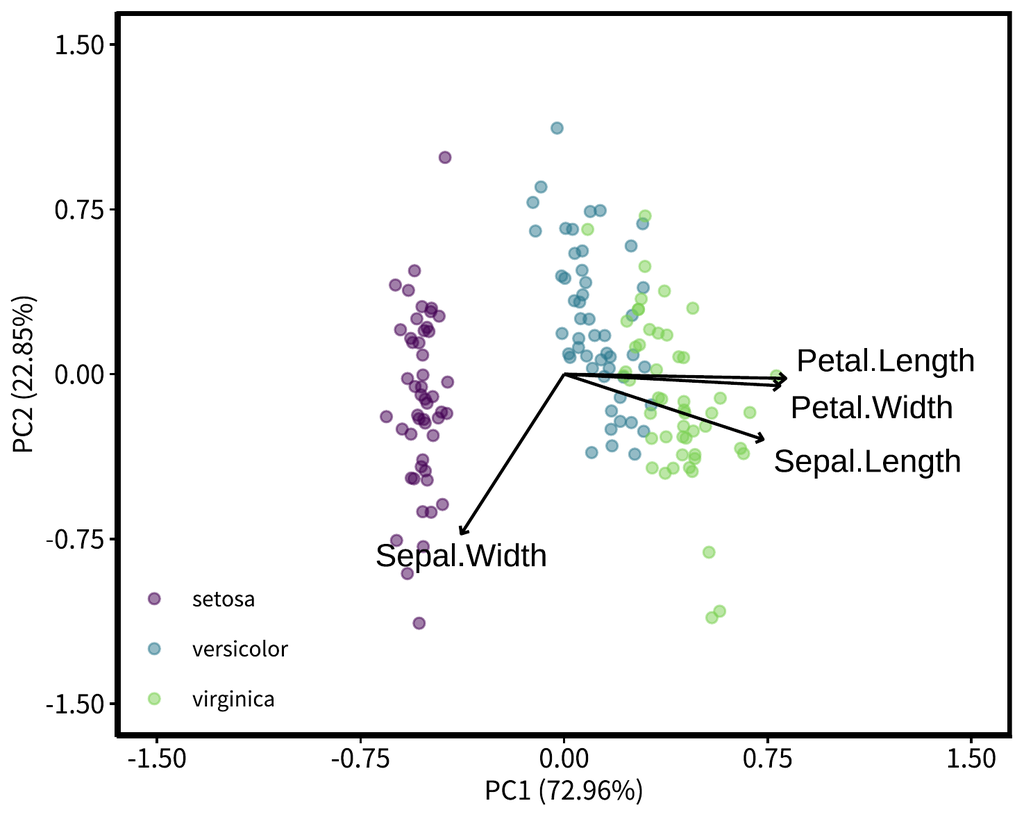

## References

Jolliffe, Ian T., and Jorge Cadima. 2016. “Principal Component Analysis: A Review and Recent Developments.” *Philosophical Transactions of the Royal Society A: Mathematical, Physical and Engineering Sciences* 374 (2065): 20150202. https://doi.org/10.1098/rsta.2015.0202.

“Principal Component Analysis for Special Types of Data.” 2002. In *Principal Component Analysis*, 338–72. New York, NY: Springer New York. https://doi.org/10.1007/0-387-22440-8_13.